# TP1

MOHAMED_AHMED_MOHAMED_LEMINE ~~ Mohamedou_Chrif_M’Hamed

# Exercise 1 – copule logistique

$$C(u,v) = 1/(1/u+1/v-1)$$

## Question 1

On a $V|U=u$ a pour FDR
$$F_{V|U=u}(v) = \frac{1}{ (1+\frac{u}{v} - u)^2 }$$

donc on trouve l’inverse de FDR de $V|U=u$

$$F^{-1}_{V|U=u}(p) = \frac{u}{u - 1 + \frac{1}{\sqrt{p}}}$$

L’algorithme est le suivant :

1. Simulation de $U$, qui suit une loi uniforme sur $[0,1]$.
2. Simulation de $W$, qui suit également une loi uniforme sur $[0,1]$.
3. Simulation de $V$ à l’aide de la méthode d’inversion de la fonction de répartition conditionnelle en utilisant $F^{-1}_{V|U=u}(w)$.

Ainsi, on obtient le couple $(u, v)$, une simulation de $(U, V)$ selon la copule $C$.

## Question 2 :

```r
> rcoplogis <- function(n) {
+   u <- runif(n)
+   w <- runif(n)
+   v <- u / (u - 1 + 1/sqrt(w))
+   return(cbind(u,v))
+ }
```

- test avec n = 1000 :

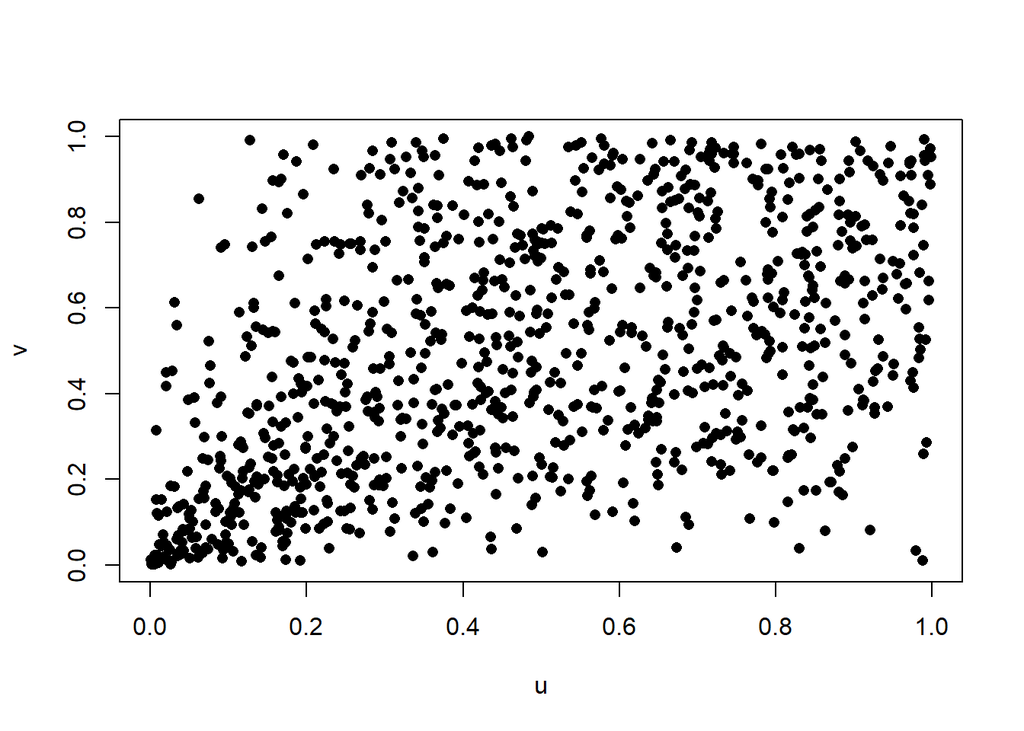

```r
> res <- rcoplogis(1000)
> plot(res ,pch=16)
```

## Question 3 :

```r
> mecdf <- function(xy)
+ {
+   f <- function(x,y)
+   {
+     mean(xy[, 1] <= x & xy[, 2] <= y)
+   }
+   Vectorize(f, c("x", "y"))
+
+ }
```

-Ce code définit une fonction qui estime empiriquement la fonction copule $C(u, v)$ en $(u, v)$, en utilisant une approche basée sur la proportion des observations dans un tableau $(xy)$ satisfaisant $X \leq u$ et $Y \leq v$.

## Question 4

```r
> pcoplogis <- function(u,v) {
+   res <- 1 / (1/u + 1/v -1)
+   return(res)
+ }
```

## Question 5

```r
> grille <- cbind(1/1:10, 1/2:11)
>
> # méthode théorique :
>
> theo_cop <- pcoplogis(grille[,1] , grille[,2])
>
> # méthode empirique :
>
> simu_u_v <- rcoplogis(1000)
>
> emp_cop <- mecdf(simu_u_v)(grille[,1] , grille[,2])
>
> # Affichage des Res :
>
> cbind("theo"=theo_cop, "emp"=emp_cop)
```

```
            theo   emp
 [1,] 0.50000000 0.511
 [2,] 0.25000000 0.261
 [3,] 0.16666667 0.182
 [4,] 0.12500000 0.131
 [5,] 0.10000000 0.106
 [6,] 0.08333333 0.084
 [7,] 0.07142857 0.081
 [8,] 0.06250000 0.063
 [9,] 0.05555556 0.058
[10,] 0.05000000 0.054
```

## Question 6

```r
> m <- 100
> verif <- cbind(runif(m) , runif(m))
> simu <- rcoplogis(1000)
>
> error <- function(verif , simu)
+ {
+     ptheao <- pcoplogis(grille[,1] , grille[,2])
+     pemp <- mecdf(simu)(grille[,1] , grille[,2])
+     mean(abs(ptheao - pemp))
+ }
>
> error(verif , simu)
```

```
[1] 0.008251587
```

## Question 7

les résultats théoriques qu’on a trouvés dans le TD sont que :

$$\lambda_L = \frac{1}{2} \\
et \\
\lambda_U = 0$$

```r
> library(copula)
> simu <- rcoplogis(1e5)
>  # Lambda L
> fitLambda(simu)[1,2]
```

```
[1] 0.5537867
```

```r
>  # Lambda U
> fitLambda(simu , lower = FALSE)[1,2]
```

```
[1] 0.0131516
```

## Question 8

```r
> rcop <- function(n) {
+   results  <- replicate(n, {
+     e <- rexp(1)
+     ech <- rexp(2, rate = e)
+     u <- 1 / (1 + ech)
+     return(u)
+   })
+
+    res <- cbind(u = results[1, ], v = results[2, ])
+
+    return(res)
+ }
```

- Test avce n = 1000

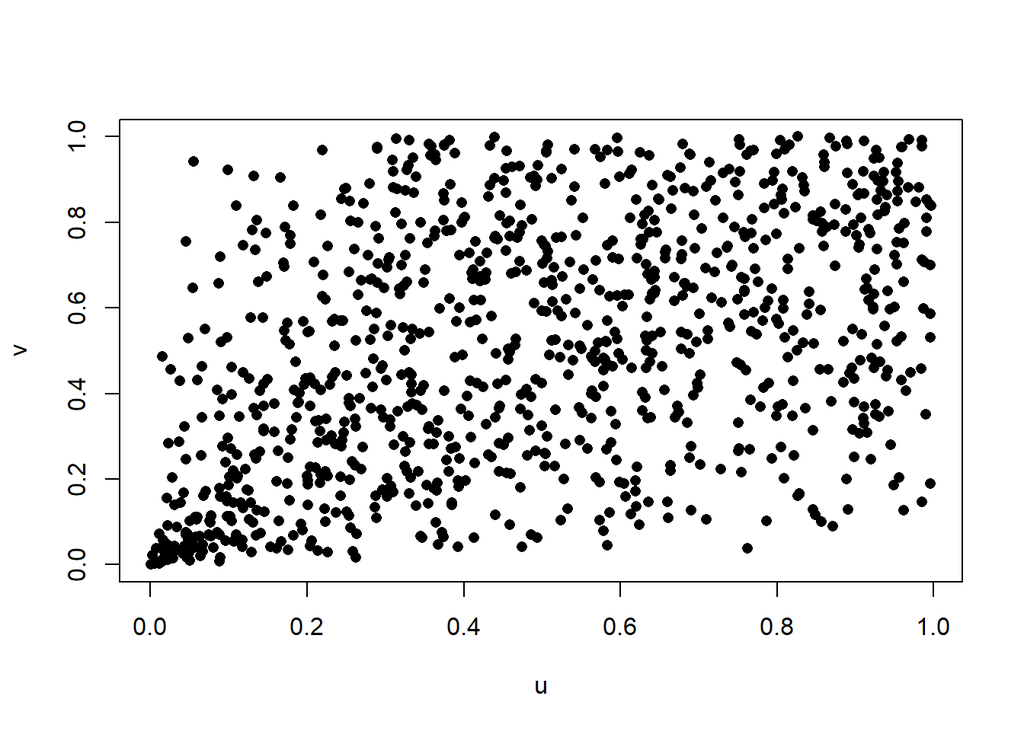

```r
> plot(rcop(1000) , pch=16)
```

- Comparaison avec la fonction C théo :

```r
> grille <- cbind(1/1:10, 1/2:11)
>
> # méthode théorique :
>
> theo_cop <- pcoplogis(grille[,1] , grille[,2])
>
> # méthode empirique :
>
> simu_u_v <- rcop(1000)
>
> emp_cop <- mecdf(simu_u_v)(grille[,1] , grille[,2])
>
> # Affichage des Res :
>
> cbind("theo"=theo_cop, "emp"=emp_cop)
```

```
            theo   emp
 [1,] 0.50000000 0.504
 [2,] 0.25000000 0.255
 [3,] 0.16666667 0.173
 [4,] 0.12500000 0.129
 [5,] 0.10000000 0.100
 [6,] 0.08333333 0.087
 [7,] 0.07142857 0.073
 [8,] 0.06250000 0.067
 [9,] 0.05555556 0.058
[10,] 0.05000000 0.055
```

- calcul de l’écart absolu moyen:

```r
> m <- 100
> verif <- cbind(runif(m) , runif(m))
> simu_u_v <- rcop(1000)
> error(verif , simu_u_v)
```

```
[1] 0.005151587
```

## Question 9

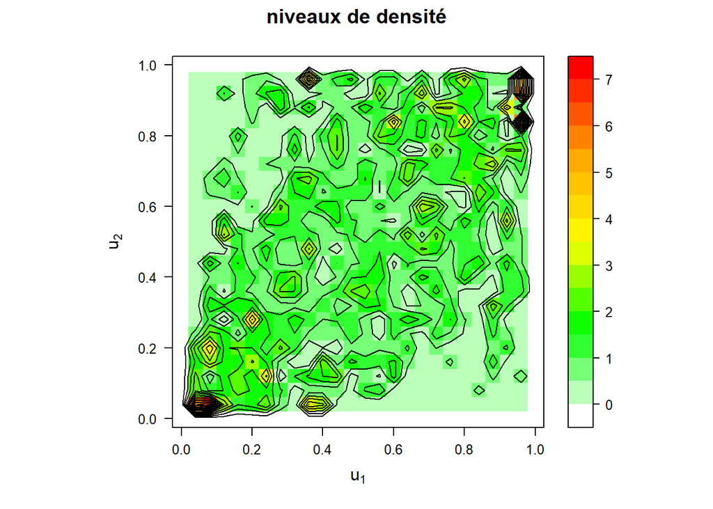

```r
> library(copula)
> n <- 1e3
> uv1 <- rcoplogis(n)
> C.hat <- empCopula(uv1, smoothing = "beta")
>
> contourplot2(C.hat, FUN=dCopula, main="niveaux de densité",
+         col.regions=colorRampPalette( c("white", "green", "yellow", "orange", "red") )(16))
```

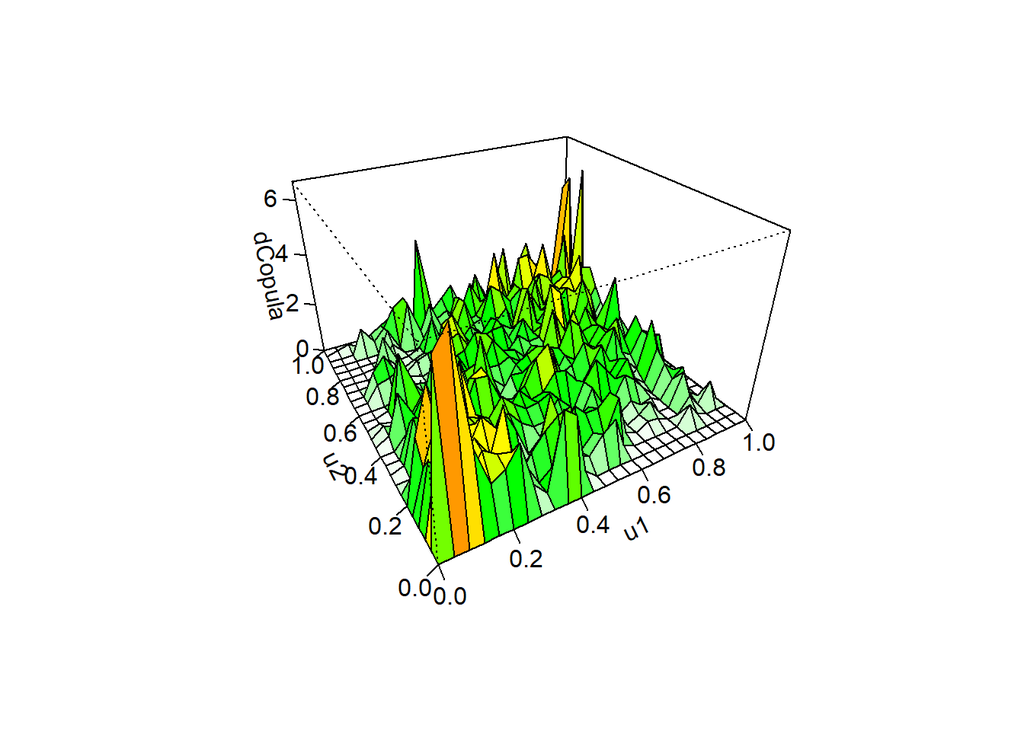

```r
> n.col <- 100
> mycolpal <- colorRampPalette( c("white","green", "yellow", "orange", "red") )(n.col)
> n.grid <- 26
> zmat <- as.matrix(expand.grid(seq(0, 1, length=n.grid),
+                               seq(0, 1, length=n.grid)))
> zmat <- matrix(dCopula(zmat, C.hat), ncol=n.grid)
> nrz <- nrow(zmat)
> ncz <- ncol(zmat)
> zctr <- zmat[-1, -1] + zmat[-1, -ncz] + zmat[-nrz, -1] + zmat[-nrz, -ncz]
> # Recode facet z-values into color indices
> facetcol <- cut(zctr, n.col)
>
> persp(C.hat, FUN=dCopula, col=mycolpal[facetcol], n.grid=n.grid)
```

## Question 10

```r
> f_inv <- function(x)
+ {
+   res <- log(x/(1-x))
+ }
>
>
>
> rcopxy <- function(n)
+ {
+   # simulation de (u,v) = (F_1(X) , F_2(Y))
+   uv <- rcop(n)
+
+   # simulation de X,Y
+   xy <- cbind(f_inv(uv[,1]) , f_inv(uv[,2]))
+
+   return(xy)
+ }
```

- Test avec n = 1000 :

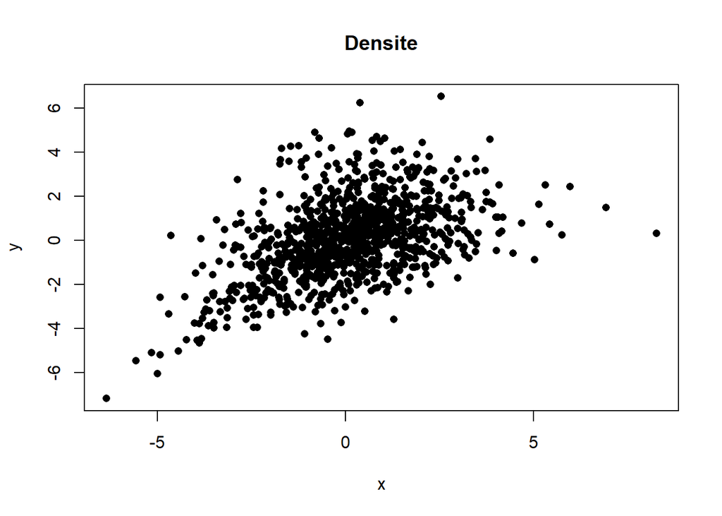

```r
> n = 1000
> xy <- rcopxy(n)
> plot(xy , pch=16 , xlab="x" , ylab="y" , main="Densite")
```

- pour valider la fonction de simulation, on peut comparer le graphe de densité avec celui théorique. On a :
  $$f_{X,Y}(x,y) = \frac{e^{-x}e^{-y}}{(1+e^{-x}+e^{-y})^3}$$

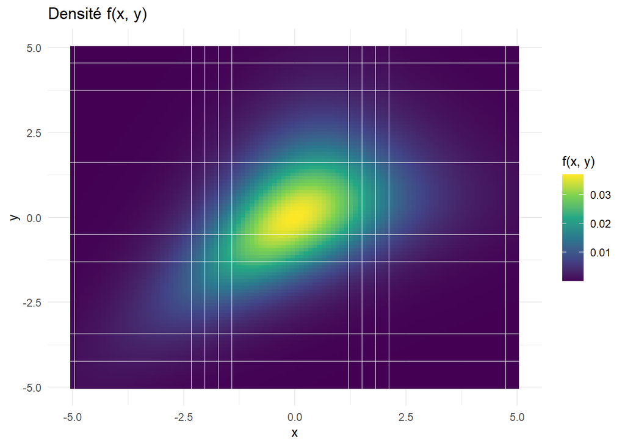

```r
> # Définition de la fonction de densité f(x, y)
> f_xy <- function(x, y) {
+   a <- exp(-x) * exp(-y)
+   b <- (1 + exp(-x) + exp(-y))^3
+   return(a / b)
+ }
>
> # Créer une grille de valeurs pour x et y
> x_vals <- seq(-5, 5, length.out = 100)
> y_vals <- seq(-5, 5, length.out = 100)
>
> # Créer la grille 2D
> grid <- expand.grid(x = x_vals, y = y_vals)
>
> # Calculer la densité f(x, y) pour chaque point de la grille
> grid$f_xy <- mapply(f_xy, grid$x, grid$y)
>
> # Tracer la densité avec un graphique contour
> library(ggplot2)
> ggplot(grid, aes(x = x, y = y, z = f_xy)) +
+   geom_tile(aes(fill = f_xy), width = 0.1, height = 0.1) +
+   scale_fill_viridis_c() +
+   labs(title = "Densité f(x, y)", x = "x", y = "y", fill = "f(x, y)") +
+   theme_minimal()
```

- donc on observe que l’on trouve la même densité graphiquement, ce qui valide la méthode de simulation de X, Y .